# edgeR analysis of Haifeng’s data

This document details the analysis of proteomics data acquired to look at A673 cells in 2D and 3D growth conditions with modulation of EWS-FLI1. We want to make comparisons between batches, so we need to do some sort of normalization to facilitate that. The purpose of the work below is to use the Internal Reference Scaling method. This method is discussed in great detail on the [GitHub page](https://github.com/pwilmart/IRS_normalization) of Phil Wilmart. I strongly encourage you to visit his site, as it is a fantastic resource for all things proteomic!

## Setting up the environment

These are packages you will need for this notebook. For exact versions used, please refer to the session info at the bottom of this notebook.

```r
##########################################################################################
library('tidyverse')
library('ggplot2')
library('RColorBrewer')
library('limma')
library('edgeR')
```

I want to set a base directory that we can use as a link to the directory where we will do most of the work. I use two directories here because the Workspace is what is pushed to GitHub and contains scripts and plot files, but the Repository is where more of the big data is stored that does not get pushed.

```r
##########################################################################################
generalDatasets = 'C:/Users/chughes/Documents/bccrc/projectsRepository/generalDatasets'
baseWorkspace = 'C:/Users/chughes/Documents/bccrc/projectsWorkspace/sorensenLab/relatedToOthers'
baseRepository = 'C:/Users/chughes/Documents/bccrc/projectsRepository/sorensenLab/relatedToOthers'
#generalDatasets = 'C:/Users/chris/OneDrive/Documents/bccrc/projectsRepository/generalDatasets'
#baseWorkspace = 'C:/Users/chris/OneDrive/Documents/bccrc/projectsWorkspace/sorensenLab/relatedToYbx1'
#baseRepository = 'C:/Users/chris/OneDrive/Documents/bccrc/projectsRepository/sorensenLab/relatedToYbx1'
```

## Data processing

Read in the normalized data.

```r
##########################################################################################
dataIrsRaw = as.data.frame(readRDS(paste(baseRepository, '/proteomics20201115_haifengA673Dox2d3dSetB/dataset_proteinSet2d3dIrsNormalized.rds', sep = '')))
row.names(dataIrsRaw) = dataIrsRaw$accession
dataIrs = dataIrsRaw[,2:19]
```

Need to set up the experimental design.

```r
##########################################################################################
# set up the sample mapping
group = rep(c('noDox2d','yesDox2d','washOut2d','noDox3d','yesDox3d','washOut3d'), each = 3)

# make group into factors and set the order
group = factor(group, levels = c('noDox2d','yesDox2d','washOut2d','noDox3d','yesDox3d','washOut3d'))
str(group)
```

```
 Factor w/ 6 levels "noDox2d","yesDox2d",..: 1 1 1 2 2 2 3 3 3 4 ...
```

```r
# create a DGEList object with our data
yIrs = DGEList(counts = dataIrs, group = group)

# y_sl is a list: y_sl$counts is the data, and y_sl$samples has interesting content
yIrs$samples
```

|  | group | lib.size | norm.factors |
| --- | --- | --- | --- |
| noDox2d.1_sum | noDox2d | 65059694872 | 1 |
| noDox2d.2_sum | noDox2d | 65085323602 | 1 |
| noDox2d.3_sum | noDox2d | 65046342206 | 1 |
| yesDox2d.1_sum | yesDox2d | 65026657211 | 1 |
| yesDox2d.2_sum | yesDox2d | 65011863064 | 1 |
| yesDox2d.3_sum | yesDox2d | 65026827926 | 1 |
| washOut2d.1_sum | washOut2d | 65044542180 | 1 |
| washOut2d.2_sum | washOut2d | 65054892268 | 1 |
| washOut2d.3_sum | washOut2d | 65064257503 | 1 |
| noDox3d.1_sum | noDox3d | 69225975643 | 1 |

[output cut: 8 more lines]

```r
# we will skip applying TMM normalization (using the calcNormFactors function)
# we need to estimate the dispersion terms (global and local)
yIrs = estimateDisp(yIrs)
```

```
Design matrix not provided. Switch to the classic mode.
```

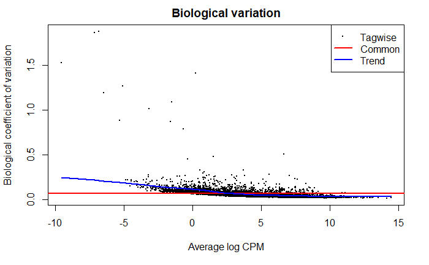

```r
plotBCV(yIrs, main = 'Biological variation')
```

Check what this looks like from a differential expression standpoint.

```r
##########################################################################################
# the exact test object has columns like fold-change, CPM, and p-values
groupOfInterestA = 'yesDox3d'
groupOfInterestB = 'noDox3d'
etIrs = exactTest(yIrs, pair = c(groupOfInterestA, groupOfInterestB))

# this counts up, down, and unchanged genes
summary(decideTestsDGE(etIrs))
```

```
       noDox3d-yesDox3d
Down               2316
NotSig             1365
Up                 3945
```

This looks mostly as expected, a lot of significant genes. Assign some FDR values and look at the overall results.

```r
##########################################################################################
# the topTags function adds the BH FDR values to an exactTest data frame. Make sure we do not change the row order!
ttIrs = topTags(etIrs, n = Inf, sort.by = "none")
ttIrs = ttIrs$table #We just need the data frame table

# add the default value as a new column
ttIrs$candidate = "no"
ttIrs[which(ttIrs$FDR <= 0.10 & ttIrs$FDR > 0.05), dim(ttIrs)[2]] = "low"
ttIrs[which(ttIrs$FDR <= 0.05 & ttIrs$FDR > 0.01), dim(ttIrs)[2]] = "med"
ttIrs[which(ttIrs$FDR <= 0.01), dim(ttIrs)[2]] = "high"
ttIrs$candidate = factor(ttIrs$candidate, levels = c("high", "med", "low", "no"))

# what does ttIrs look like?
head(ttIrs)
```

|  | logFC | logCPM | PValue | FDR | candidate |
| --- | --- | --- | --- | --- | --- |
| A0A024R1R8 | 0.3939387 | 4.327007 | 1.906366e-20 | 5.712355e-20 | high |
| A0A024RBG1 | 0.8901011 | 5.484056 | 3.280809e-80 | 4.420398e-79 | high |
| A0A087WUV0 | 0.2146685 | 2.729586 | 1.423561e-04 | 2.111667e-04 | high |
| A0A096LP55 | 0.7095902 | 1.653568 | 5.228221e-19 | 1.488813e-18 | high |
| A0A0B4J2D5 | -0.4269790 | 6.681048 | 2.147331e-35 | 1.022832e-34 | high |
| A0A0B4J2E5 | 0.5771002 | 5.219863 | 1.545184e-29 | 6.182356e-29 | high |

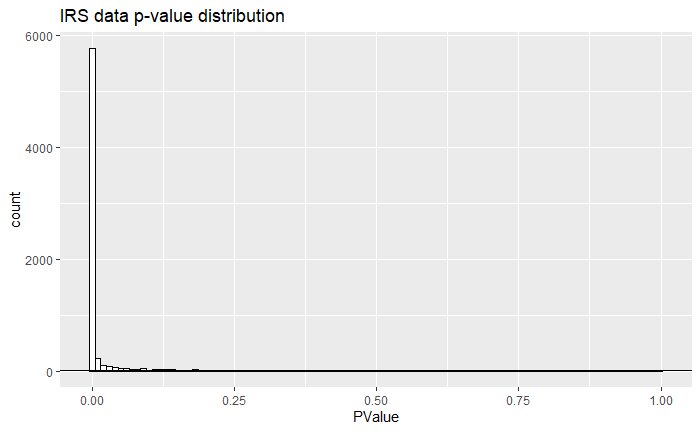

```r
# what does the test p-value distribution look like?
ggplot(ttIrs, aes(PValue)) +
  geom_histogram(bins = 100, fill = "white", color = "black") +
  geom_hline(yintercept = mean(hist(ttIrs$PValue, breaks = 100, plot = FALSE)$counts[26:100])) +
  ggtitle("IRS data p-value distribution")
```

Make some plots of the results.

```r
##########################################################################################
samplesA = c(which(grepl(groupOfInterestA, colnames(dataIrs))))
samplesB = c(which(grepl(groupOfInterestB, colnames(dataIrs))))
deIrs = data.frame(rowMeans(dataIrs[samplesA]), rowMeans(dataIrs[samplesB]), ttIrs$candidate)
colnames(deIrs) = c('samplesA','samplesB', 'candidate')
head(deIrs)
```

|  | samplesA | samplesB | candidate |
| --- | --- | --- | --- |
| A0A024R1R8 | 1082430.6 | 1420350.3 | high |
| A0A024RBG1 | 1806400.5 | 3343304.8 | high |
| A0A087WUV0 | 376340.3 | 436124.7 | high |
| A0A096LP55 | 160193.8 | 261618.1 | high |
| A0A0B4J2D5 | 9477102.6 | 7039711.4 | high |
| A0A0B4J2E5 | 1938228.1 | 2887621.3 | high |

```r
# we need the transformed data for the volcano plot
volcanoIrs = data.frame(-1*ttIrs$logFC, -1*log10(ttIrs$FDR), ttIrs$candidate)
colnames(volcanoIrs) = c("FoldChange", "FDR", "candidate")
head(volcanoIrs)
```

|  | FoldChange | FDR | candidate |
| --- | --- | --- | --- |
| 1 | -0.3939387 | 19.243185 | high |
| 2 | -0.8901011 | 78.354539 | high |
| 3 | -0.2146685 | 3.675375 | high |
| 4 | -0.7095902 | 17.827160 | high |
| 5 | 0.4269790 | 33.990196 | high |
| 6 | -0.5771002 | 28.208846 | high |

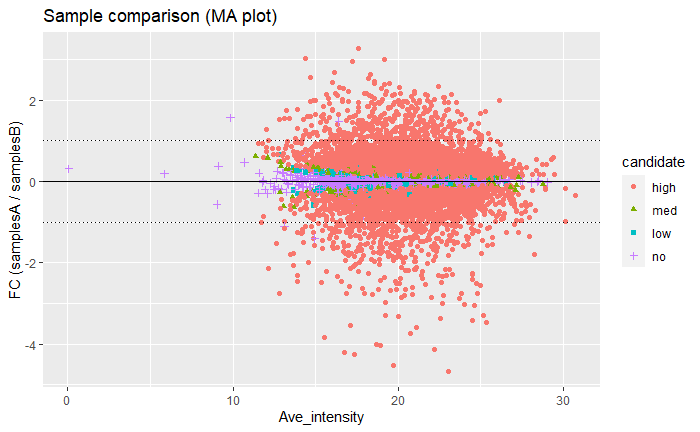

```r
# start with MA plot
temp = data.frame(log2((deIrs$samplesA + deIrs$samplesB)/2), log2(deIrs$samplesB/deIrs$samplesA), deIrs$candidate)
colnames(temp) = c("Ave", "FC", "candidate")
ggplot(temp, aes(x = Ave, y = FC)) +
  geom_point(aes(color = candidate, shape = candidate)) +
  scale_y_continuous("FC (samplesA / samplesB)") +
  scale_x_continuous("Ave_intensity") +
  ggtitle("Sample comparison (MA plot)") +
  geom_hline(yintercept = 0.0, color = "black") + # one-to-one line
  geom_hline(yintercept = 1.0, color = "black", linetype = "dotted") + # 2-fold up
  geom_hline(yintercept = -1.0, color = "black", linetype = "dotted") # 2-fold down
```

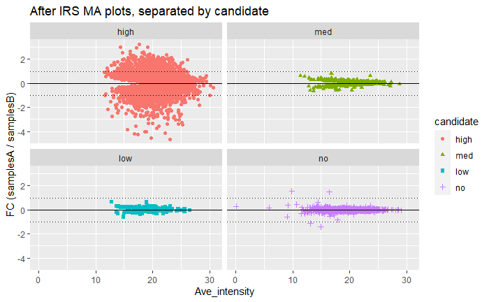

```r
# make separate MA plots
ggplot(temp, aes(x = Ave, y = FC)) +
  geom_point(aes(color = candidate, shape = candidate)) +
  scale_y_continuous("FC (samplesA / samplesB)") +
  scale_x_continuous("Ave_intensity") +
  geom_hline(yintercept = 0.0, color = "black") + # one-to-one line
  geom_hline(yintercept = 1.0, color = "black", linetype = "dotted") + # 2-fold up
  geom_hline(yintercept = -1.0, color = "black", linetype = "dotted") + # 2-fold down
  facet_wrap(~ candidate) +
  ggtitle("After IRS MA plots, separated by candidate")
```

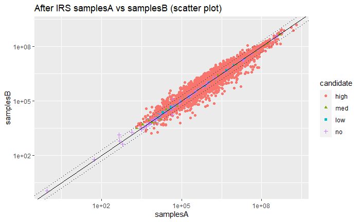

```r
# make the combined candidate corelation plot
ggplot(deIrs, aes(x = samplesA, y = samplesB)) +
  geom_point(aes(color = candidate, shape = candidate)) +
  scale_y_log10() +
  scale_x_log10() +
  ggtitle("After IRS samplesA vs samplesB (scatter plot)") +
  geom_abline(intercept = 0.0, slope = 1.0, color = "black") + # one-to-one line
  geom_abline(intercept = 0.301, slope = 1.0, color = "black", linetype = "dotted") + # 2-fold up
  geom_abline(intercept = -0.301, slope = 1.0, color = "black", linetype = "dotted") # 2-fold down
```

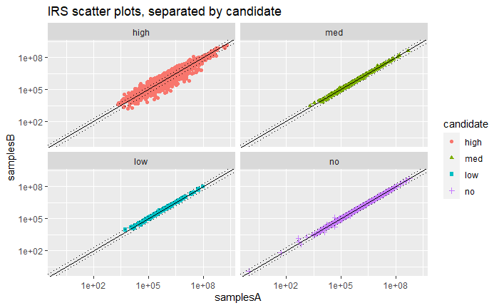

```r
# make separate corelation plots
ggplot(deIrs, aes(x = samplesA, y = samplesB)) +
  geom_point(aes(color = candidate, shape = candidate)) +
  scale_y_log10() +
  scale_x_log10() +
  geom_abline(intercept = 0.0, slope = 1.0, color = "black") + # one-to-one line
  geom_abline(intercept = 0.301, slope = 1.0, color = "black", linetype = "dotted") + # 2-fold up
  geom_abline(intercept = -0.301, slope = 1.0, color = "black", linetype = "dotted") + # 2-fold down
  facet_wrap(~ candidate) +
  ggtitle("IRS scatter plots, separated by candidate")
```

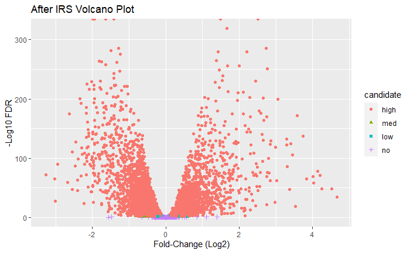

```r
# make a volcano plot
ggplot(volcanoIrs, aes(x = FoldChange, y = FDR)) +
  geom_point(aes(color = candidate, shape = candidate)) +
  xlab("Fold-Change (Log2)") +
  ylab("-Log10 FDR") +
  ggtitle("After IRS Volcano Plot")
```

Reassign some of he annotation.

```r
##########################################################################################
volcanoIrs$accession = dataIrsRaw$accession
volcanoIrs$gene = dataIrsRaw$gene
##
volcanoIrs[grepl('^IL1RAP$', volcanoIrs$gene),]
```

|  | FoldChange | FDR | candidate | accession | gene |
| --- | --- | --- | --- | --- | --- |
| 6473 | -1.722895 | 43.48624 | high | Q9NPH3 | IL1RAP |

```r
volcanoIrs[grepl('^DLG2$', volcanoIrs$gene),]
```

|  | FoldChange | FDR | candidate | accession | gene |
| --- | --- | --- | --- | --- | --- |
| 3327 | -1.569773 | 98.79107 | high | Q15700 | DLG2 |

```r
##save the data
write.table(volcanoIrs,
            paste(baseRepository, '/proteomics20201115_haifengA673Dox2d3dSetA/dataset_edgerIrs_',groupOfInterestA,'-',groupOfInterestB,'.csv', sep = ''),
            sep = ',', row.names = FALSE, quote = FALSE)
```

[session information not shown]